# Linear_Regression_Exercise

Xu Yang

12/5/2017

# Exercise: least squares regression

────────────────────────────────────────

Use the /states.rds/ data set. Fit a model predicting energy consumed per capita (energy) from the percentage of residents living in metropolitan areas (metro). Be sure to 1. Examine/plot the data before fitting the model 2. Print and interpret the model `summary' 3.`plot’ the model to look for deviations from modeling assumptions

Select one or more additional predictors to add to your model and repeat steps 1-3. Is this model significantly better than the model with /metro/ as the only predictor?

```r
states_energy<-subset(states.data, select=pop:college)
cor(states_energy)
```

```
##         pop area density metro waste energy miles toxic green house senate
## pop       1   NA      NA    NA    NA     NA    NA    NA    NA    NA     NA
## area     NA    1      NA    NA    NA     NA    NA    NA    NA    NA     NA
## density  NA   NA       1    NA    NA     NA    NA    NA    NA    NA     NA
## metro    NA   NA      NA     1    NA     NA    NA    NA    NA    NA     NA
## waste    NA   NA      NA    NA     1     NA    NA    NA    NA    NA     NA
## energy   NA   NA      NA    NA    NA      1    NA    NA    NA    NA     NA
## miles    NA   NA      NA    NA    NA     NA     1    NA    NA    NA     NA
## toxic    NA   NA      NA    NA    NA     NA    NA     1    NA    NA     NA
## green    NA   NA      NA    NA    NA     NA    NA    NA     1    NA     NA
## house    NA   NA      NA    NA    NA     NA    NA    NA    NA     1     NA
## senate   NA   NA      NA    NA    NA     NA    NA    NA    NA    NA      1
## csat     NA   NA      NA    NA    NA     NA    NA    NA    NA    NA     NA
## vsat     NA   NA      NA    NA    NA     NA    NA    NA    NA    NA     NA
## msat     NA   NA      NA    NA    NA     NA    NA    NA    NA    NA     NA
## percent  NA   NA      NA    NA    NA     NA    NA    NA    NA    NA     NA
## expense  NA   NA      NA    NA    NA     NA    NA    NA    NA    NA     NA
## income   NA   NA      NA    NA    NA     NA    NA    NA    NA    NA     NA
## high     NA   NA      NA    NA    NA     NA    NA    NA    NA    NA     NA
## college  NA   NA      NA    NA    NA     NA    NA    NA    NA    NA     NA
##                csat        vsat       msat    percent    expense
## pop              NA          NA         NA         NA         NA
## area             NA          NA         NA         NA         NA
## density          NA          NA         NA         NA         NA
## metro            NA          NA         NA         NA         NA
## waste            NA          NA         NA         NA         NA
## energy           NA          NA         NA         NA         NA
## miles            NA          NA         NA         NA         NA
## toxic            NA          NA         NA         NA         NA
## green            NA          NA         NA         NA         NA
## house            NA          NA         NA         NA         NA
## senate           NA          NA         NA         NA         NA
## csat     1.00000000  0.99131150  0.9930342 -0.8758060 -0.4662978
## vsat     0.99131150  1.00000000  0.9689079 -0.8712266 -0.4725056
## msat     0.99303418  0.96890785  1.0000000 -0.8669911 -0.4538597
## percent -0.87580602 -0.87122662 -0.8669911  1.0000000  0.6509347
## expense -0.46629785 -0.47250560 -0.4538597  0.6509347  1.0000000
## income  -0.47126014 -0.50251926 -0.4363083  0.6733453  0.6784117
## high     0.08577774  0.04912712  0.1173435  0.1413027  0.3132790
## college -0.37294328 -0.38099075 -0.3602340  0.6090646  0.6399959
##             income       high    college
## pop             NA         NA         NA
## area            NA         NA         NA
## density         NA         NA         NA
## metro           NA         NA         NA
## waste           NA         NA         NA
## energy          NA         NA         NA
## miles           NA         NA         NA
## toxic           NA         NA         NA
## green           NA         NA         NA
## house           NA         NA         NA
## senate          NA         NA         NA
## csat    -0.4712601 0.08577774 -0.3729433
## vsat    -0.5025193 0.04912712 -0.3809907
## msat    -0.4363083 0.11734353 -0.3602340
## percent  0.6733453 0.14130271  0.6090646
## expense  0.6784117 0.31327902  0.6399959
## income   1.0000000 0.50990813  0.7233540
## high     0.5099081 1.00000000  0.5318763
## college  0.7233540 0.53187628  1.0000000
```

```r
energy.mod1<- lm(energy ~ metro,data=na.omit(states.data))
summary(energy.mod1)
```

```
##
## Call:
## lm(formula = energy ~ metro, data = na.omit(states.data))
##
## Residuals:
##     Min      1Q  Median      3Q     Max
## -179.17  -54.21  -21.64   15.07  448.02
##
## Coefficients:
##             Estimate Std. Error t value Pr(>|t|)
## (Intercept) 449.8382    50.4472   8.917 1.37e-11 ***
## metro        -1.6526     0.7428  -2.225    0.031 *
## ---
## Signif. codes:  0 '***' 0.001 '**' 0.01 '*' 0.05 '.' 0.1 ' ' 1
##
## Residual standard error: 112.3 on 46 degrees of freedom
## Multiple R-squared:  0.09714,    Adjusted R-squared:  0.07751
## F-statistic: 4.949 on 1 and 46 DF,  p-value: 0.03105
```

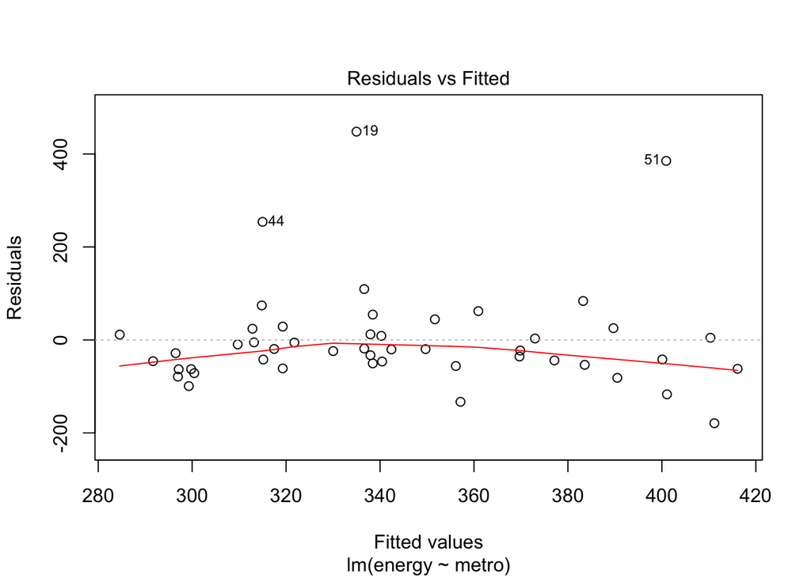

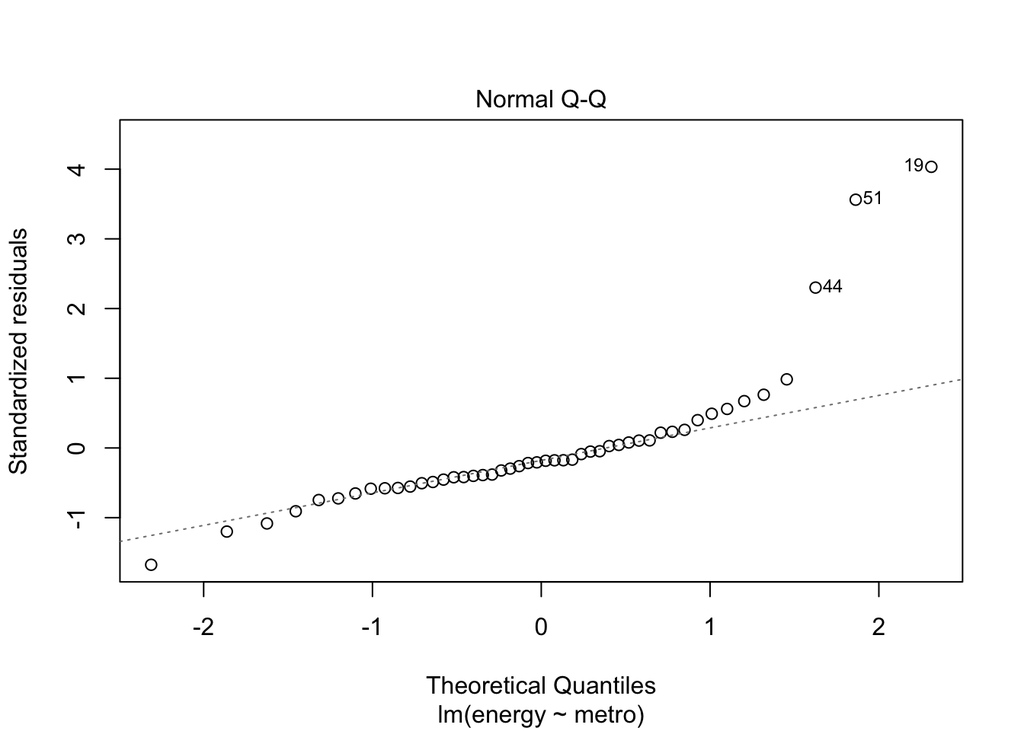

```r
plot(energy.mod1, which = c(1, 2))
```

```r
energy.mod2<- lm(energy ~ metro+pop+area+density+waste+energy+miles+toxic+green+house+senate, data=na.omit(states.data))
summary(energy.mod2)
```

```
##
## Call:
## lm(formula = energy ~ metro + pop + area + density + waste +
##     energy + miles + toxic + green + house + senate, data = na.omit(states.data))
##
## Residuals:
##      Min       1Q   Median       3Q      Max
## -171.558  -22.583   -6.458   24.641  166.971
##
## Coefficients:
##               Estimate Std. Error t value Pr(>|t|)
## (Intercept)  3.224e+01  1.283e+02   0.251    0.803
## metro        2.769e-01  7.062e-01   0.392    0.697
## pop          2.410e-07  2.477e-06   0.097    0.923
## area         3.442e-04  2.710e-04   1.270    0.212
## density      2.621e-02  6.477e-02   0.405    0.688
## waste        4.853e+00  4.892e+01   0.099    0.922
## miles        1.073e+01  1.168e+01   0.919    0.364
## toxic        2.651e+00  5.649e-01   4.692 3.64e-05 ***
## green        4.490e+00  7.892e-01   5.689 1.66e-06 ***
## house        1.092e-01  8.551e-01   0.128    0.899
## senate      -3.568e-03  5.624e-01  -0.006    0.995
## ---
## Signif. codes:  0 '***' 0.001 '**' 0.01 '*' 0.05 '.' 0.1 ' ' 1
##
## Residual standard error: 60.62 on 37 degrees of freedom
## Multiple R-squared:  0.7885, Adjusted R-squared:  0.7313
## F-statistic: 13.79 on 10 and 37 DF,  p-value: 1.085e-09
```

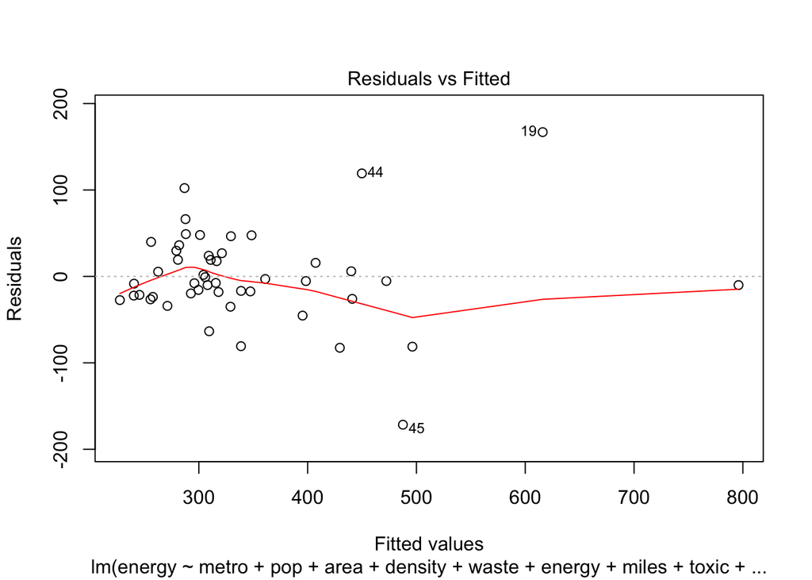

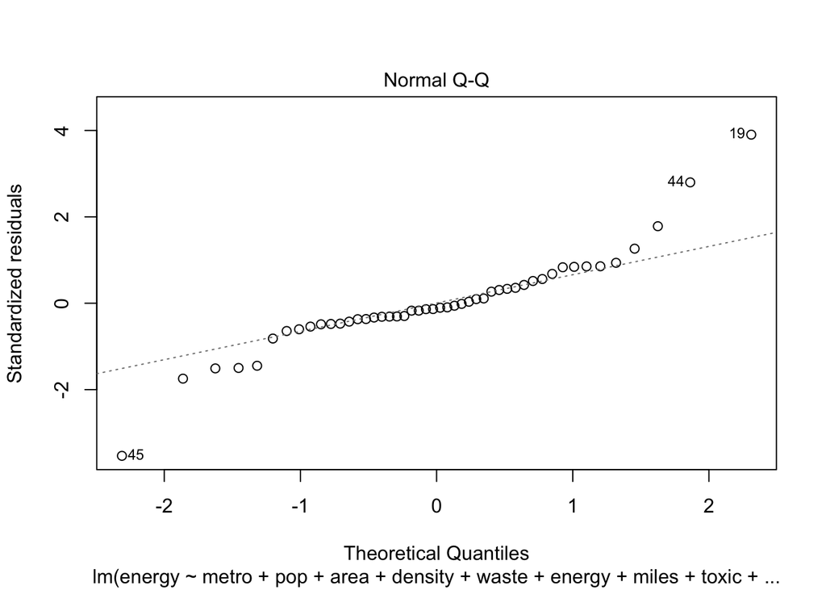

```r
plot(energy.mod2, which = c(1, 2))
```

From the summary, we can see it seems just toxic and green are significant variables. The R-squared is 0.7885, and Adjusted R-squared is 0.7313, they are both quite higher than energy.mod1’s. Residuals’ range became smaller around 50%.  
Let’s just keep toxic and green.

```r
energy.mod3<-lm(energy ~ metro+toxic+green, data=na.omit(states.data))
summary(energy.mod3)
```

```
##
## Call:
## lm(formula = energy ~ metro + toxic + green, data = na.omit(states.data))
##
## Residuals:
##      Min       1Q   Median       3Q      Max
## -179.311  -31.415   -4.114   17.108  191.943
##
## Coefficients:
##             Estimate Std. Error t value Pr(>|t|)
## (Intercept) 160.5506    37.4912   4.282 9.87e-05 ***
## metro         0.2437     0.4273   0.570    0.571
## toxic         2.6691     0.4730   5.643 1.13e-06 ***
## green         4.7992     0.5819   8.247 1.79e-10 ***
## ---
## Signif. codes:  0 '***' 0.001 '**' 0.01 '*' 0.05 '.' 0.1 ' ' 1
##
## Residual standard error: 58.67 on 44 degrees of freedom
## Multiple R-squared:  0.7644, Adjusted R-squared:  0.7483
## F-statistic: 47.58 on 3 and 44 DF,  p-value: 7.305e-14
```

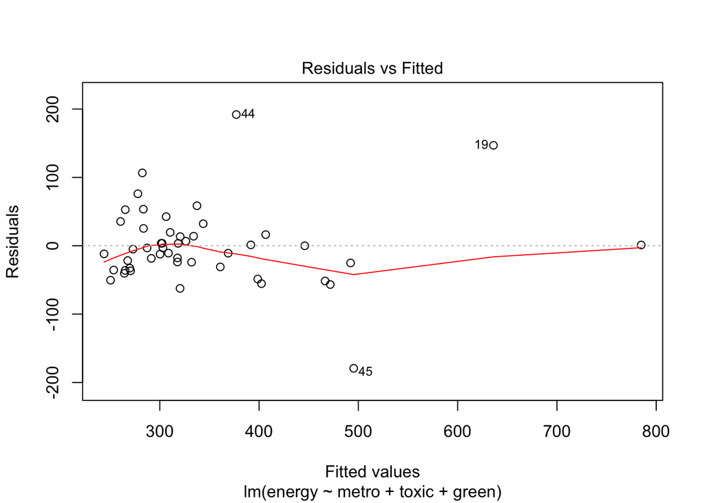

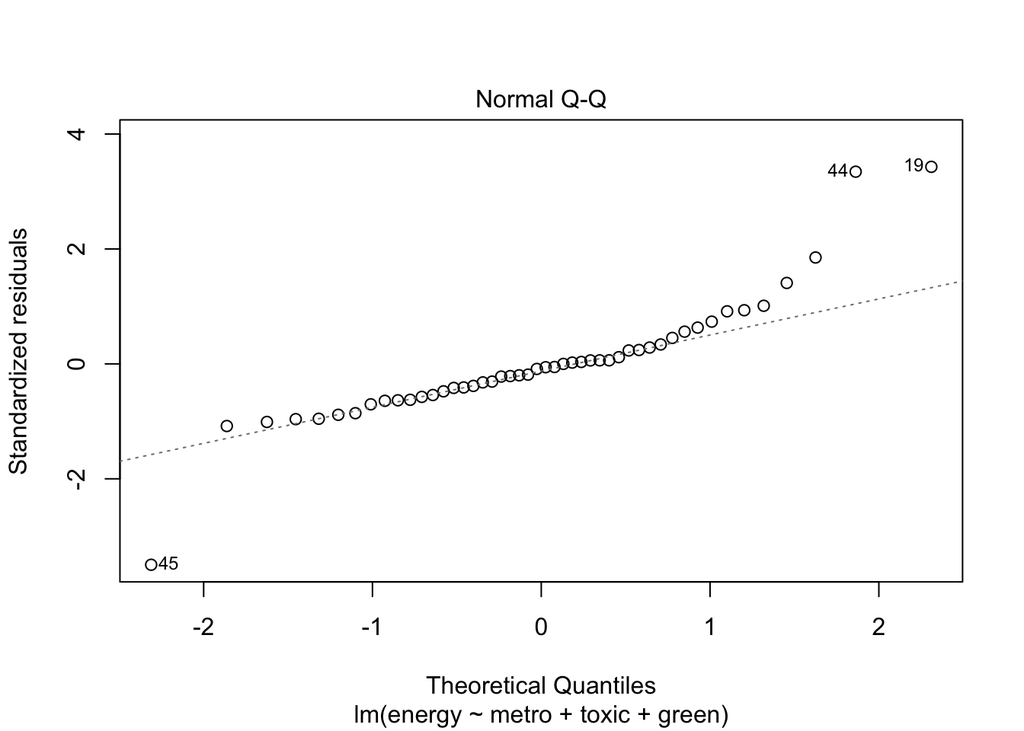

```r
plot(energy.mod3, which = c(1, 2))
```

```r
energy.mod4<-lm(energy ~ toxic+green, data=na.omit(states.data))
summary(energy.mod4)
```

```
##
## Call:
## lm(formula = energy ~ toxic + green, data = na.omit(states.data))
##
## Residuals:
##      Min       1Q   Median       3Q      Max
## -174.763  -28.685   -3.589   17.280  196.598
##
## Coefficients:
##             Estimate Std. Error t value Pr(>|t|)
## (Intercept) 179.8260    16.1194  11.156 1.51e-14 ***
## toxic         2.6455     0.4676   5.657 1.01e-06 ***
## green         4.6722     0.5336   8.756 2.81e-11 ***
## ---
## Signif. codes:  0 '***' 0.001 '**' 0.01 '*' 0.05 '.' 0.1 ' ' 1
##
## Residual standard error: 58.23 on 45 degrees of freedom
## Multiple R-squared:  0.7627, Adjusted R-squared:  0.7521
## F-statistic:  72.3 on 2 and 45 DF,  p-value: 8.835e-15
```

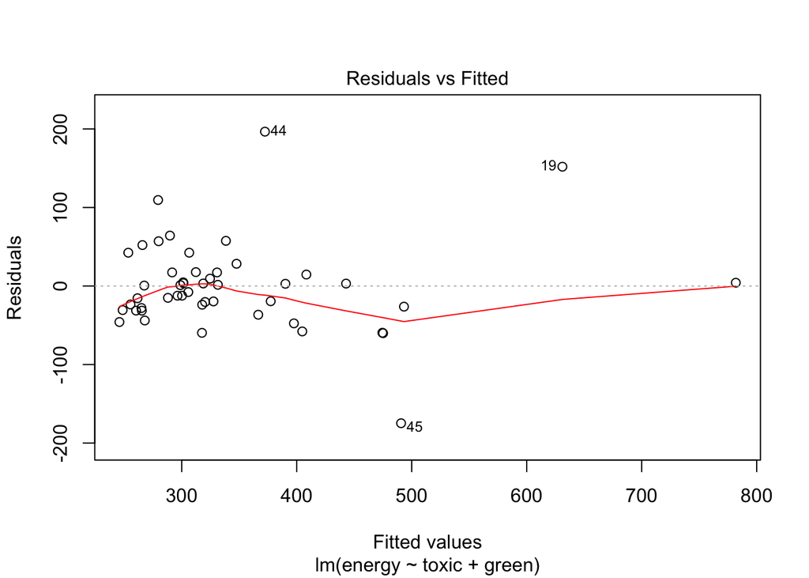

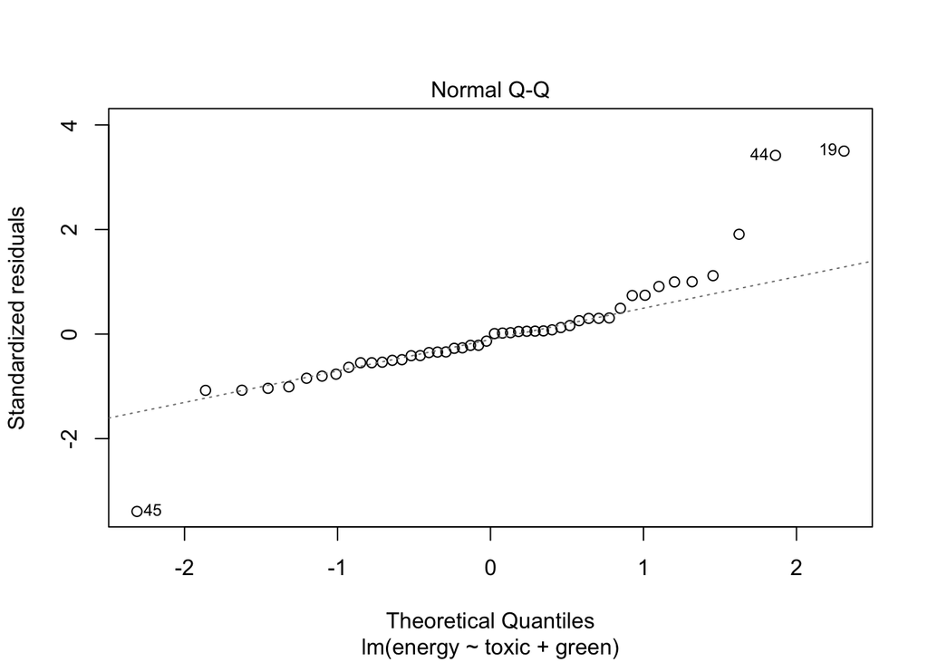

```r
plot(energy.mod4, which = c(1, 2))
```

The R-squared is 0.7627,Adjusted R-squared is 0.7521.

# Exercise: interactions and factors

────────────────────────────────────────

Use the states data set.

1. Add on to the regression equation that you created in exercise 1 by generating an interaction term and testing the interaction.
2. Try adding region to the model. Are there significant differences across the four regions?

Make sure R knows region is categorical

```r
str(states.data$region)
```

```
##  Factor w/ 4 levels "West","N. East",..: 3 1 1 3 1 1 2 3 NA 3 ...
```

```r
states.data$region <- factor(states.data$region)
```

```r
energy.mod5<-lm(energy ~ metro*toxic, data=na.omit(states.data))
summary(energy.mod5)
```

```
##
## Call:
## lm(formula = energy ~ metro * toxic, data = na.omit(states.data))
##
## Residuals:
##     Min      1Q  Median      3Q     Max
## -210.60  -48.61  -12.48   27.41  378.47
##
## Coefficients:
##               Estimate Std. Error t value Pr(>|t|)
## (Intercept) 360.852143  63.346218   5.697 9.41e-07 ***
## metro        -1.207788   0.872344  -1.385    0.173
## toxic         3.026365   2.735331   1.106    0.275
## metro:toxic   0.006918   0.040134   0.172    0.864
## ---
## Signif. codes:  0 '***' 0.001 '**' 0.01 '*' 0.05 '.' 0.1 ' ' 1
##
## Residual standard error: 93.58 on 44 degrees of freedom
## Multiple R-squared:  0.4006, Adjusted R-squared:  0.3597
## F-statistic: 9.801 on 3 and 44 DF,  p-value: 4.529e-05
```

```r
energy.mod6<-lm(energy ~ metro*green, data=na.omit(states.data))
summary(energy.mod6)
```

```
##
## Call:
## lm(formula = energy ~ metro * green, data = na.omit(states.data))
##
## Residuals:
##     Min      1Q  Median      3Q     Max
## -121.09  -35.90  -11.83   17.70  256.93
##
## Coefficients:
##              Estimate Std. Error t value Pr(>|t|)
## (Intercept) 294.75648   47.81417   6.165 1.93e-07 ***
## metro        -2.79577    0.87647  -3.190  0.00262 **
## green        -0.15677    1.59485  -0.098  0.92214
## metro:green   0.15836    0.04096   3.867  0.00036 ***
## ---
## Signif. codes:  0 '***' 0.001 '**' 0.01 '*' 0.05 '.' 0.1 ' ' 1
##
## Residual standard error: 66.55 on 44 degrees of freedom
## Multiple R-squared:  0.6969, Adjusted R-squared:  0.6762
## F-statistic: 33.72 on 3 and 44 DF,  p-value: 1.787e-11
```

For energy.mod5, R-squared is 0.4006, Adjusted R-squeared is 0.3597, Pr for metro:toxic is 0.864 For energy.mod6, R-squared is 0.6969, Adjusted R-squeared is 0.6762, Pr for metro:green is 0.00036, for metro is 0.00262 which means metro became significant in this model.

```r
energy.mod7<-lm(energy ~ metro*green+toxic, data=na.omit(states.data))
summary(energy.mod7)
```

```
##
## Call:
## lm(formula = energy ~ metro * green + toxic, data = na.omit(states.data))
##
## Residuals:
##      Min       1Q   Median       3Q      Max
## -171.457  -25.400   -8.605   23.928  166.399
##
## Coefficients:
##              Estimate Std. Error t value Pr(>|t|)
## (Intercept) 214.22653   45.10283   4.750 2.29e-05 ***
## metro        -1.21522    0.83774  -1.451  0.15415
## green         2.09522    1.46308   1.432  0.15936
## toxic         2.17429    0.52006   4.181  0.00014 ***
## metro:green   0.07949    0.03970   2.002  0.05159 .
## ---
## Signif. codes:  0 '***' 0.001 '**' 0.01 '*' 0.05 '.' 0.1 ' ' 1
##
## Residual standard error: 56.76 on 43 degrees of freedom
## Multiple R-squared:  0.7845, Adjusted R-squared:  0.7644
## F-statistic: 39.13 on 4 and 43 DF,  p-value: 8.351e-14
```

enery.mod7 has highest Adjust R-squared with 0.7644, and it’s R-squared is 0.7845,just little bit lower than energy.mod2.

Let’s see region

```r
energy.mod8<-lm(energy ~ region, data=na.omit(states.data))
summary(energy.mod8)
```

```
##
## Call:
## lm(formula = energy ~ region, data = na.omit(states.data))
##
## Residuals:
##     Min      1Q  Median      3Q     Max
## -143.13  -50.13  -23.62   17.36  418.82
##
## Coefficients:
##               Estimate Std. Error t value Pr(>|t|)
## (Intercept)     367.18      33.25  11.044 2.87e-14 ***
## regionN. East  -118.07      49.56  -2.382   0.0216 *
## regionSouth      12.94      43.19   0.300   0.7658
## regionMidwest   -23.18      46.03  -0.504   0.6170
## ---
## Signif. codes:  0 '***' 0.001 '**' 0.01 '*' 0.05 '.' 0.1 ' ' 1
##
## Residual standard error: 110.3 on 44 degrees of freedom
## Multiple R-squared:  0.1677, Adjusted R-squared:  0.111
## F-statistic: 2.956 on 3 and 44 DF,  p-value: 0.04268
```

```r
anova(energy.mod8)
```

```
## Analysis of Variance Table
##
## Response: energy
##           Df Sum Sq Mean Sq F value  Pr(>F)
## region     3 107818   35939  2.9555 0.04268 *
## Residuals 44 535042   12160
## ---
## Signif. codes:  0 '***' 0.001 '**' 0.01 '*' 0.05 '.' 0.1 ' ' 1
```

```r
summary(lm(energy ~ C(region, base=4),
           data=states.data))
```

```
##
## Call:
## lm(formula = energy ~ C(region, base = 4), data = states.data)
##
## Residuals:
##     Min      1Q  Median      3Q     Max
## -162.62  -58.49  -30.62   12.00  585.38
##
## Coefficients:
##                      Estimate Std. Error t value Pr(>|t|)
## (Intercept)            344.00      40.83   8.424 7.06e-11 ***
## C(region, base = 4)1    61.62      56.63   1.088    0.282
## C(region, base = 4)2   -94.89      62.37  -1.521    0.135
## C(region, base = 4)3    36.13      54.02   0.669    0.507
## ---
## Signif. codes:  0 '***' 0.001 '**' 0.01 '*' 0.05 '.' 0.1 ' ' 1
##
## Residual standard error: 141.5 on 46 degrees of freedom
##   (1 observation deleted due to missingness)
## Multiple R-squared:  0.1367, Adjusted R-squared:  0.08041
## F-statistic: 2.428 on 3 and 46 DF,  p-value: 0.07737
```

```r
summary(lm(energy ~ C(region, contr.helmert),
   data=states.data))
```

```
##
## Call:
## lm(formula = energy ~ C(region, contr.helmert), data = states.data)
##
## Residuals:
##     Min      1Q  Median      3Q     Max
## -162.62  -58.49  -30.62   12.00  585.38
##
## Coefficients:
##                           Estimate Std. Error t value Pr(>|t|)
## (Intercept)               344.7129    20.4333  16.870   <2e-16 ***
## C(region, contr.helmert)1 -78.2521    30.6690  -2.552   0.0141 *
## C(region, contr.helmert)2  17.5873    15.6032   1.127   0.2655
## C(region, contr.helmert)3  -0.2376    11.7909  -0.020   0.9840
## ---
## Signif. codes:  0 '***' 0.001 '**' 0.01 '*' 0.05 '.' 0.1 ' ' 1
##
## Residual standard error: 141.5 on 46 degrees of freedom
##   (1 observation deleted due to missingness)
## Multiple R-squared:  0.1367, Adjusted R-squared:  0.08041
## F-statistic: 2.428 on 3 and 46 DF,  p-value: 0.07737
```

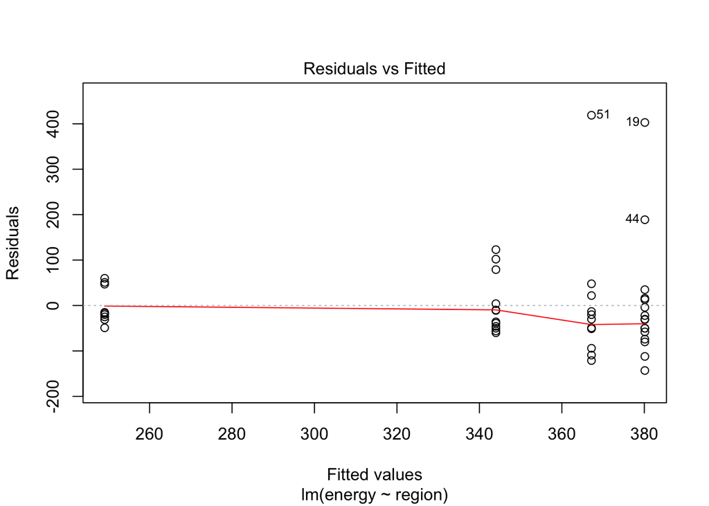

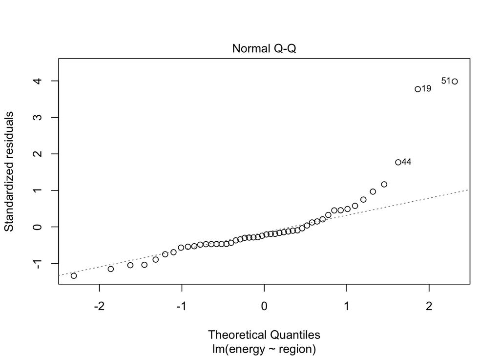

```r
plot(energy.mod8,which=c(1,2))
```

The summary of energy.mod8 shows that the R-squared is 0.1677, and Adjusted R-squared is 0.111. Juest region N.East is significant. There is no strong linear relationship between energy and region.